# 04_generate_brainmaps

Roxanne Leblanc

2026-05-27

```r
library(dplyr)
library(readr)
library(emmeans)
```

```r
library(ggplot2)
library(stringr)
library(tidyr)
library(lme4)
library(lmerTest)
library(purrr)
library(here)
options(scipen = 999)

library(ggseg)
library(ggsegDestrieux)
library(ggseg3d)

library(zip)
```

# Importation des données

Unzip les fichiers de données.

```r
utils::unzip(
  zipfile = here("results", "tables", "tables.zip"),
  exdir = here("results", "tables")
)
```

Plusieurs post-hocs ont été faits à partir des interactions co_longi x session_id significatives. Pour l’épaisseur corticale avec les atlas desikan et destrieux, les post-hocs ont été faits avec 1) le temps comme variable catégorielle pour visualiser 1.1) les différences de moyennes entre les groupes à chaque temps de mesure et 1.2) les différences de pentes à travers le temps entre les groupes et 2) le temps comme variable continue. (6 post-hocs)

Pour le volume de matière grise avec les atlas desikan, destrieux, les post-hocs ont été faits avec 1) le temps comme variable catégorielle pour visualiser 1.1) les différences de moyennes entre les groupes à chaque temps de mesure et 1.2) les différences de pentes à travers le temps entre les groupes et 2) le temps comme variable continue. (6 post-hocs)

Pour le volume de matière grise avec la segmentation sous-corticale, les modèles ont été roulés séparément pour les régions retrouvées bilatéralement et unilatéralement, car l’hémisphère ne pouvait être inclus dans le modèle pour les régions unilatérales. Pour chacun des modèles, les post-hocs ont été faits avec 1) le temps comme variable catégorielle pour visualiser 1.1) les différences de moyennes entre les groupes à chaque temps de mesure et 1.2) les différences de pentes à travers le temps entre les groupes et 2) le temps comme variable continue. (6 post-hocs)

Total de 18 post-hocs - 1 tableau par post-hoc

```r
# épaisseur corticale

posthoc_ct_dsk <- read.csv(here("results", "tables", "posthoc_ct_dsk.csv")) # temps catégoriel, différences de moyennes entre les groupes à chaque temps de mesure
posthoc_ct_dsk_pente <- read.csv(here("results", "tables", "posthoc_ct_dsk_pente.csv"))# temps catégoriel, différences de pentes entre les groupes
posthoc_ct_dsk_continu <- read.csv(here("results", "tables", "posthoc_ct_dsk_continu.csv"))# temps continu

posthoc_ct_dst <- read.csv(here("results", "tables", "posthoc_ct_dst.csv")) # temps catégoriel, différences de moyennes entre les groupes à chaque temps de mesure
posthoc_ct_dst_pente <- read.csv(here("results", "tables", "posthoc_ct_dst_pente.csv")) # temps catégoriel, différences de pentes entre les groupes
posthoc_ct_dst_continu <- read.csv(here("results", "tables", "posthoc_ct_dst_continu.csv"))# temps continu

# volume de matière grise

posthoc_vol_dsk <- read.csv(here("results", "tables", "posthoc_vol_dsk.csv")) # temps catégoriel, différences de moyennes entre les groupes à chaque temps de mesure
posthoc_vol_dsk_pente <- read.csv(here("results", "tables","posthoc_vol_dsk_pente.csv")) # temps catégoriel, différences de pentes entre les groupes
posthoc_vol_dsk_continu <- read.csv(here("results", "tables", "posthoc_vol_dsk_continu.csv")) # temps continu

posthoc_vol_dst <- read.csv(here("results", "tables", "posthoc_vol_dst.csv")) # temps catégoriel, différences de moyennes entre les groupes à chaque temps de mesure
posthoc_vol_dst_pente <- read.csv(here("results", "tables", "posthoc_vol_dst_pente.csv")) # temps catégoriel, différences de pentes entre les groupes
posthoc_vol_dst_continu <- read.csv(here("results", "tables", "posthoc_vol_dst_continu.csv"))# temps continu

posthoc_vol_aseg <- read.csv(here("results", "tables", "posthoc_vol_aseg.csv")) # régions bilatérales, temps catégoriel, différences de moyennes entre les groupes à chaque temps de mesure
posthoc_vol_aseg_pente <- read.csv(here("results", "tables", "posthoc_vol_aseg_pente.csv")) # régions bilatérales,temps catégoriel, différences de pentes entre les groupes
posthoc_vol_aseg_continu <- read.csv(here("results", "tables", "posthoc_vol_aseg_continu.csv")) # régions bilatérales,temps continu

posthoc_vol_aseg_uni <- read.csv(here("results", "tables", "posthoc_vol_aseg_uni.csv")) # régions unilatérales, temps catégoriel, différences de moyennes entre les groupes à chaque temps de mesure
posthoc_vol_aseg_uni_pente <- read.csv(here("results", "tables", "posthoc_vol_aseg_uni_pente.csv")) # régions unilatérales,temps catégoriel, différences de pentes entre les groupes
posthoc_vol_aseg_continu_uni <- read.csv(here("results", "tables", "posthoc_vol_aseg_continu_uni.csv")) # régions unilatérales,temps continu
```

# temps catégoriel, différences de moyennes entre les groupes à chaque temps de mesure

```r
ggseg.formats::atlas_regions(dk())
```

```
##  [1] "banks of superior temporal sulcus" "caudal anterior cingulate"
##  [3] "caudal middle frontal"             "corpus callosum"
##  [5] "cuneus"                            "entorhinal"
##  [7] "frontal pole"                      "fusiform"
##  [9] "inferior parietal"                 "inferior temporal"
## [11] "insula"                            "isthmus cingulate"
## [13] "lateral occipital"                 "lateral orbitofrontal"
## [15] "lingual"                           "medial orbitofrontal"
## [17] "middle temporal"                   "paracentral"
## [19] "parahippocampal"                   "pars opercularis"
## [21] "pars orbitalis"                    "pars triangularis"
## [23] "pericalcarine"                     "postcentral"
## [25] "posterior cingulate"               "precentral"
## [27] "precuneus"                         "rostral anterior cingulate"
## [29] "rostral middle frontal"            "superior frontal"
## [31] "superior parietal"                 "superior temporal"
## [33] "supramarginal"                     "temporal pole"
## [35] "transverse temporal"
```

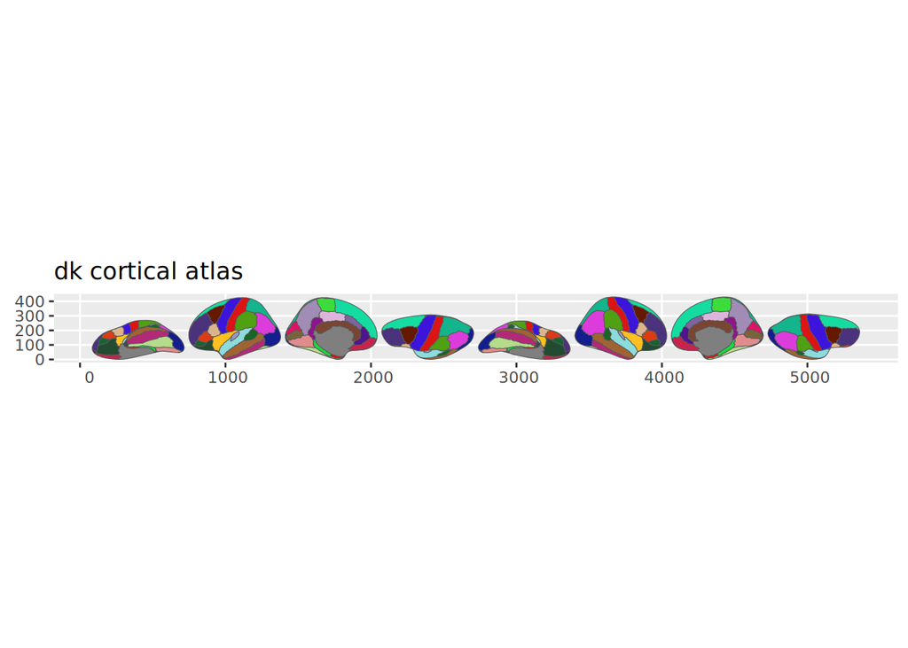

```r
# changer les noms dans les tableaux pour que ca fit avec ceux de l'atlas
posthoc_ct_dsk <- posthoc_ct_dsk %>%
  mutate(region = recode(region,

    "mr_y_smri__thk__dsk__bstmps" = "banks of superior temporal sulcus",
    "mr_y_smri__thk__dsk__cac"    = "caudal anterior cingulate",
    "mr_y_smri__thk__dsk__cmfrt"  = "caudal middle frontal",
    "mr_y_smri__thk__dsk__cn"     = "cuneus",
    "mr_y_smri__thk__dsk__er"     = "entorhinal",
    "mr_y_smri__thk__dsk__ff"     = "fusiform",
    "mr_y_smri__thk__dsk__ic"     = "isthmuscingulate",
    "mr_y_smri__thk__dsk__ins"    = "insula",
    "mr_y_smri__thk__dsk__iprt"   = "inferior parietal",
    "mr_y_smri__thk__dsk__itmp"   = "inferior temporal",
    "mr_y_smri__thk__dsk__lg"     = "lingual",
    "mr_y_smri__thk__dsk__lobfrt" = "lateral orbitofrontal",
    "mr_y_smri__thk__dsk__locc"   = "lateral occipital",
    "mr_y_smri__thk__dsk__mobfrt" = "medial orbitofrontal",
    "mr_y_smri__thk__dsk__mtmp"   = "middle temporal",
    "mr_y_smri__thk__dsk__pactr"  = "paracentral",
    "mr_y_smri__thk__dsk__pcc"    = "pericalcarine",
    "mr_y_smri__thk__dsk__pcg"    = "posterior cingulate",
    "mr_y_smri__thk__dsk__pfrt"   = "frontal pole",
    "mr_y_smri__thk__dsk__ph"     = "parahippocampal",
    "mr_y_smri__thk__dsk__pob"    = "pars orbitalis",
    "mr_y_smri__thk__dsk__poctr"  = "postcentral",
    "mr_y_smri__thk__dsk__pop"    = "pars opercularis",
    "mr_y_smri__thk__dsk__prcn"   = "precuneus",
    "mr_y_smri__thk__dsk__prctr"  = "precentral",
    "mr_y_smri__thk__dsk__ptg"    = "pars triangularis",
    "mr_y_smri__thk__dsk__ptmp"   = "temporal pole",
    "mr_y_smri__thk__dsk__rac"    = "rostral anterior cingulate",
    "mr_y_smri__thk__dsk__rmfrt"  = "rostral middle frontal",
    "mr_y_smri__thk__dsk__sfrt"   = "superior frontal",
    "mr_y_smri__thk__dsk__sm"     = "supramarginal",
    "mr_y_smri__thk__dsk__sprt"   = "superior parietal",
    "mr_y_smri__thk__dsk__stmp"   = "superior temporal",
    "mr_y_smri__thk__dsk__ttmp"   = "transverse temporal"

  ))

posthoc_ct_dsk_0_1 <- posthoc_ct_dsk %>%
  filter(contrast == "co_longi0 - co_longi1")

posthoc_ct_dsk_0_1_ses02 <- posthoc_ct_dsk_0_1 %>%
  filter(session_id == "ses-02A")

posthoc_ct_dsk_0_1_ses04 <- posthoc_ct_dsk_0_1 %>%
  filter(session_id == "ses-04A")

posthoc_ct_dsk_0_1_ses06 <- posthoc_ct_dsk_0_1 %>%
  filter(session_id == "ses-06A")

plot(dk())
```

```
## Merging atlas and data by region.
```

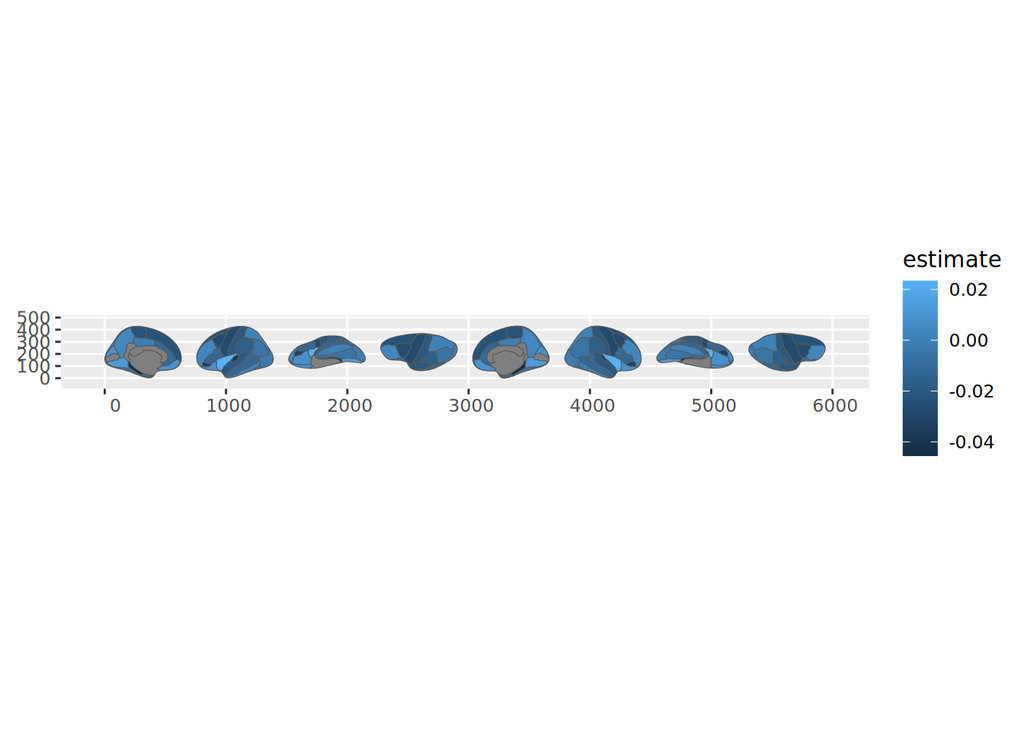

```r
# 2
ggplot(posthoc_ct_dsk_0_1_ses02) +
  geom_brain(
    atlas = dk(),
    mapping = aes(fill = estimate)
  )
```

```
## Merging atlas and data by region.
```

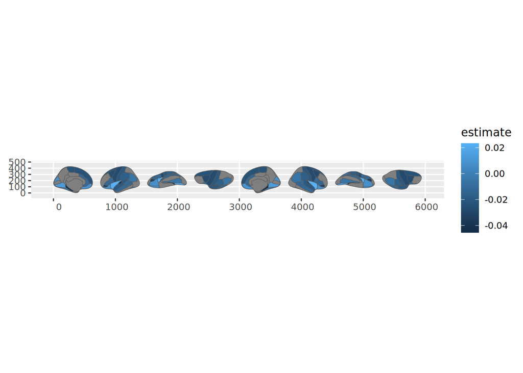

```r
ggplot(posthoc_ct_dsk_0_1_ses02 %>% filter(p.value < 0.05)) +
  geom_brain(
    atlas = dk(),
    aes(fill = estimate)
  )
```

```
## Merging atlas and data by region.
```

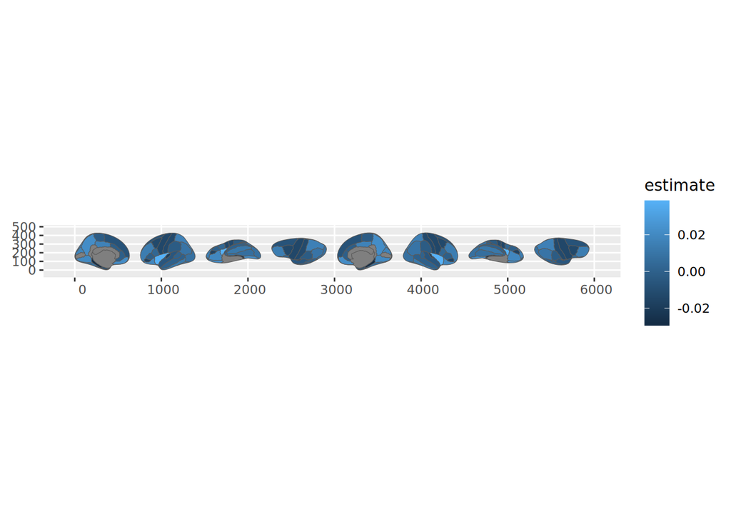

```r
# 4
ggplot(posthoc_ct_dsk_0_1_ses04) +
  geom_brain(
    atlas = dk(),
    mapping = aes(fill = estimate)
  )
```

```
## Merging atlas and data by region.
```

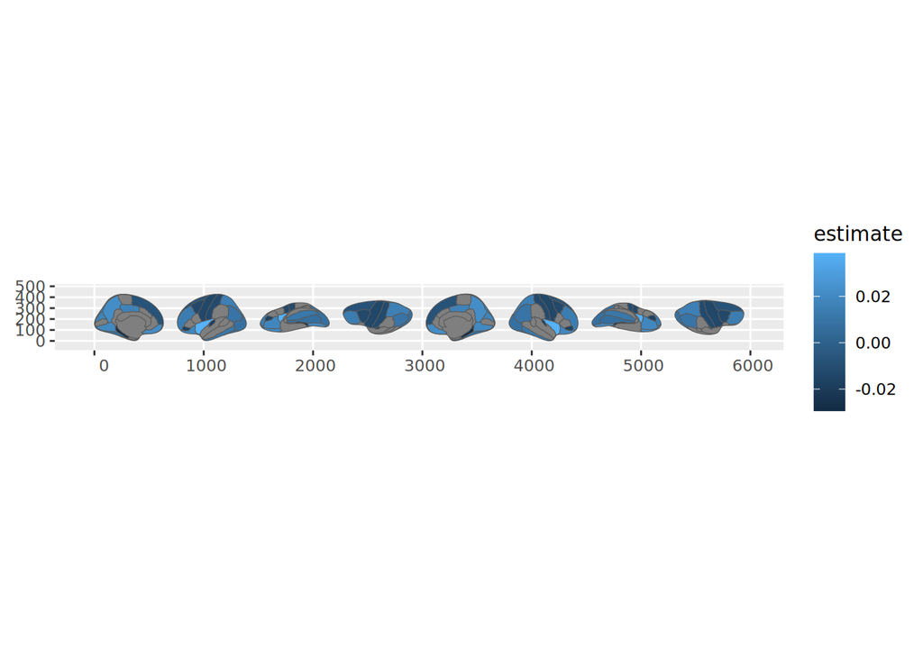

```r
ggplot(posthoc_ct_dsk_0_1_ses04 %>% filter(p.value < 0.05)) +
  geom_brain(
    atlas = dk(),
    aes(fill = estimate)
  )
```

```
## Merging atlas and data by region.
```

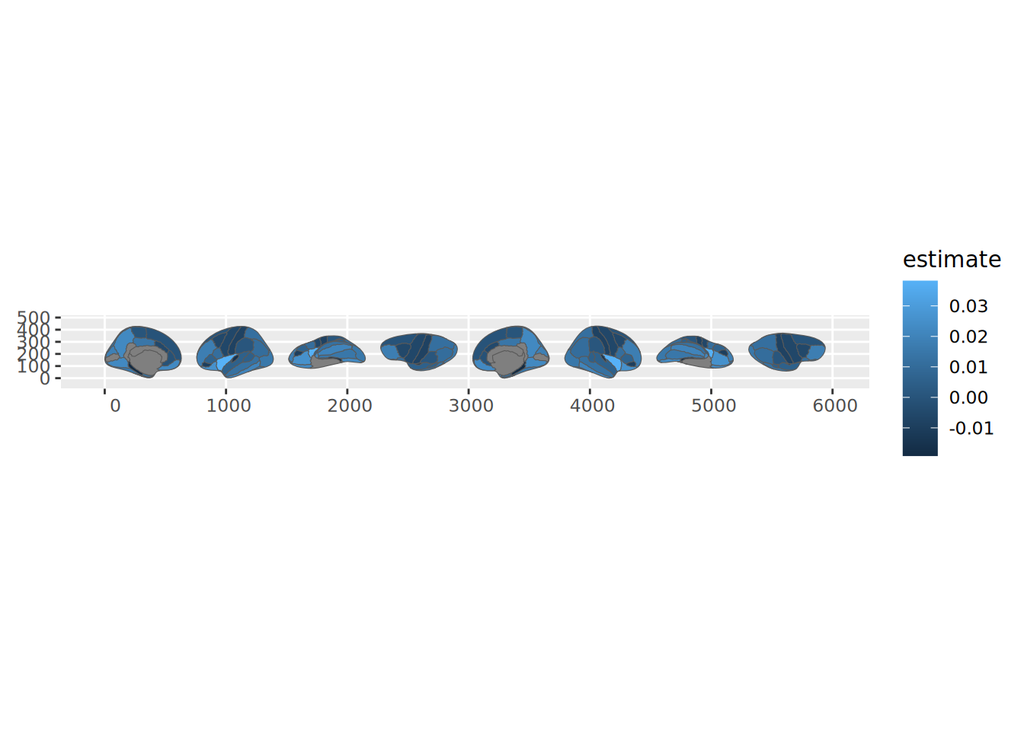

```r
# 6
ggplot(posthoc_ct_dsk_0_1_ses06) +
  geom_brain(
    atlas = dk(),
    mapping = aes(fill = estimate)
  )
```

```
## Merging atlas and data by region.
```

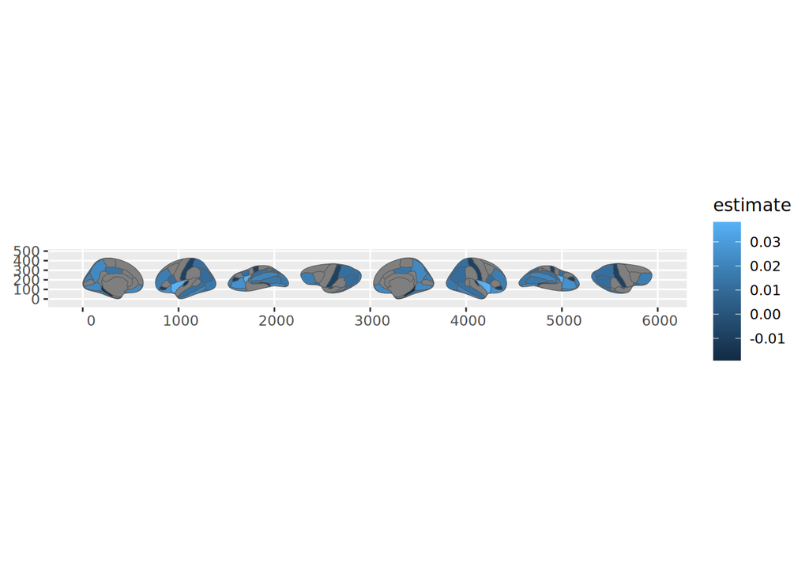

```r
ggplot(posthoc_ct_dsk_0_1_ses06 %>% filter(p.value < 0.05)) +
  geom_brain(
    atlas = dk(),
    aes(fill = estimate)
  )
```

```
## Merging atlas and data by region.
```

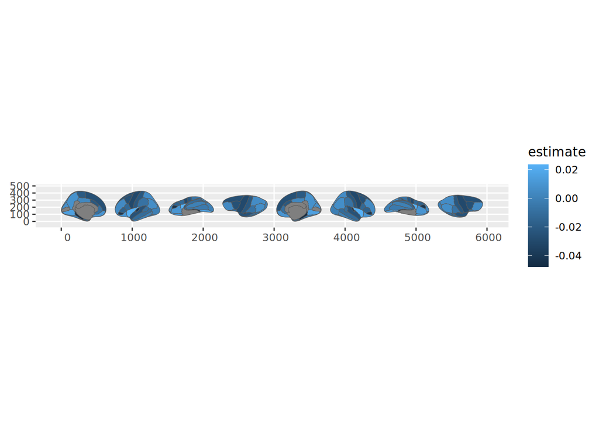

```r
posthoc_ct_dsk_0_2 <- posthoc_ct_dsk %>%
  filter(contrast == "co_longi0 - co_longi2")

posthoc_ct_dsk_0_2_ses02 <- posthoc_ct_dsk_0_2 %>%
  filter(session_id == "ses-02A")

posthoc_ct_dsk_0_2_ses04 <- posthoc_ct_dsk_0_2 %>%
  filter(session_id == "ses-04A")

posthoc_ct_dsk_0_2_ses06 <- posthoc_ct_dsk_0_2 %>%
  filter(session_id == "ses-06A")

# 2
ggplot(posthoc_ct_dsk_0_2_ses02) +
  geom_brain(
    atlas = dk(),
    mapping = aes(fill = estimate)
  )
```

```
## Merging atlas and data by region.
```

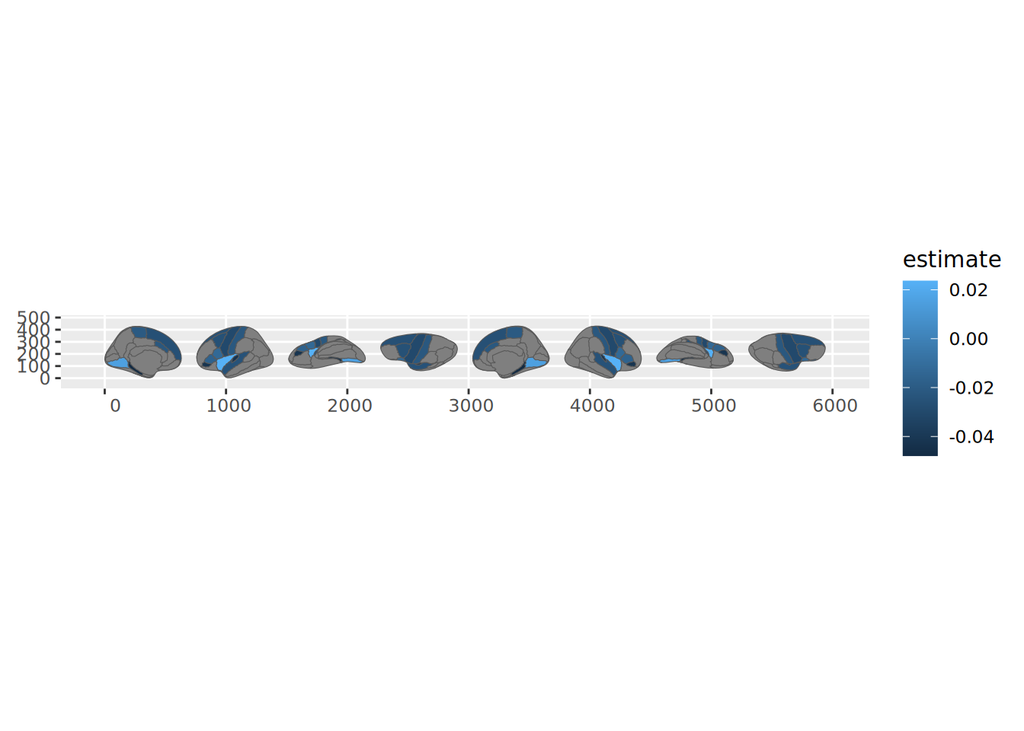

```r
ggplot(posthoc_ct_dsk_0_2_ses02 %>% filter(p.value < 0.05)) +
  geom_brain(
    atlas = dk(),
    aes(fill = estimate)
  )
```

```
## Merging atlas and data by region.
```

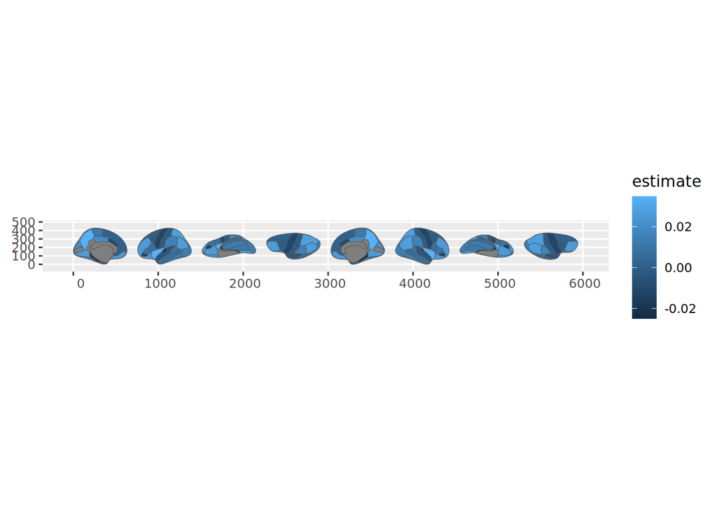

```r
# 4
ggplot(posthoc_ct_dsk_0_2_ses04) +
  geom_brain(
    atlas = dk(),
    mapping = aes(fill = estimate)
  )
```

```
## Merging atlas and data by region.
```

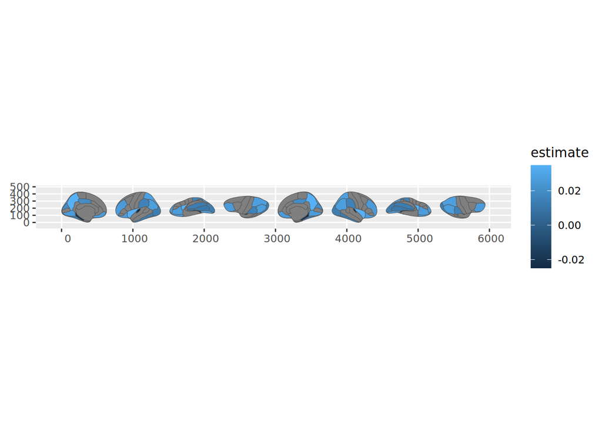

```r
ggplot(posthoc_ct_dsk_0_2_ses04 %>% filter(p.value < 0.05)) +
  geom_brain(
    atlas = dk(),
    aes(fill = estimate)
  )
```

```
## Merging atlas and data by region.
```

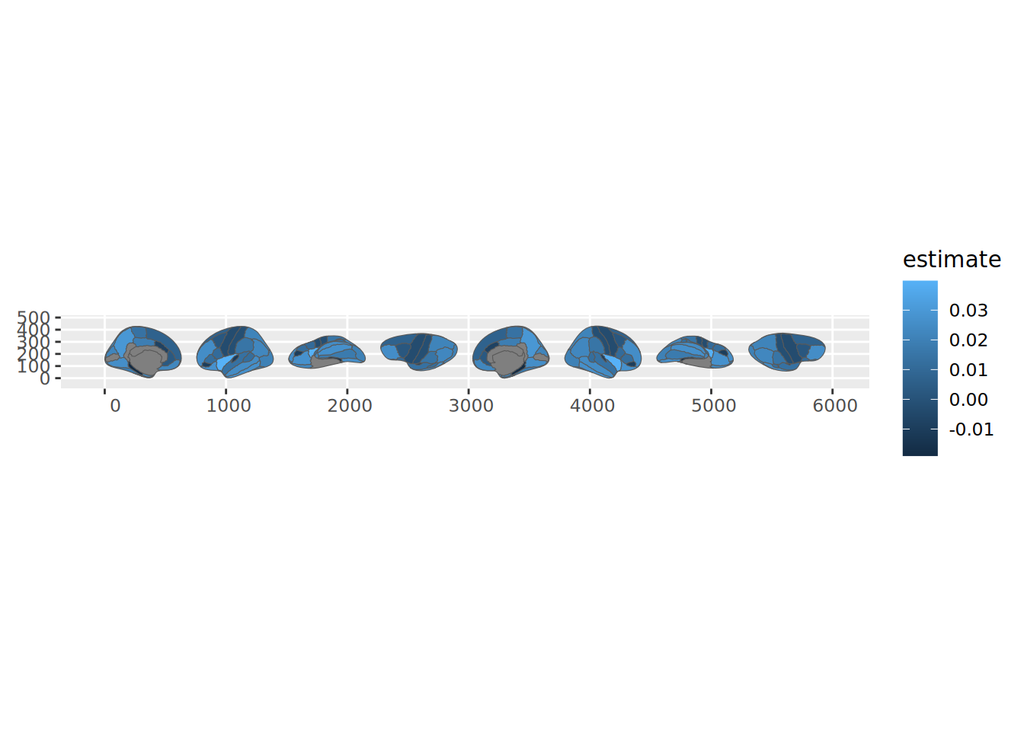

```r
# 6
ggplot(posthoc_ct_dsk_0_2_ses06) +
  geom_brain(
    atlas = dk(),
    mapping = aes(fill = estimate)
  )
```

```
## Merging atlas and data by region.
```

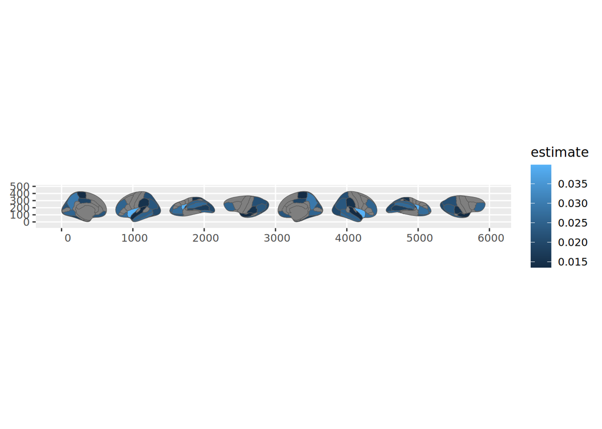

```r
ggplot(posthoc_ct_dsk_0_2_ses06 %>% filter(p.value < 0.05)) +
  geom_brain(
    atlas = dk(),
    aes(fill = estimate)
  )
```

```r
ggseg.formats::atlas_regions(destrieux())
```

```
##  [1] "G_and_S_cingul-Ant"        "G_and_S_cingul-Mid-Ant"
##  [3] "G_and_S_cingul-Mid-Post"   "G_and_S_frontomargin"
##  [5] "G_and_S_occipital_inf"     "G_and_S_paracentral"
##  [7] "G_and_S_subcentral"        "G_and_S_transv_frontopol"
##  [9] "G_cingul-Post-dorsal"      "G_cingul-Post-ventral"
## [11] "G_cuneus"                  "G_front_inf-Opercular"
## [13] "G_front_inf-Orbital"       "G_front_inf-Triangul"
## [15] "G_front_middle"            "G_front_sup"
## [17] "G_Ins_lg_and_S_cent_ins"   "G_insular_short"
## [19] "G_oc-temp_lat-fusifor"     "G_oc-temp_med-Lingual"
## [21] "G_oc-temp_med-Parahip"     "G_occipital_middle"
## [23] "G_occipital_sup"           "G_orbital"
## [25] "G_pariet_inf-Angular"      "G_pariet_inf-Supramar"
## [27] "G_parietal_sup"            "G_postcentral"
## [29] "G_precentral"              "G_precuneus"
```

[output cut: 22 more lines]

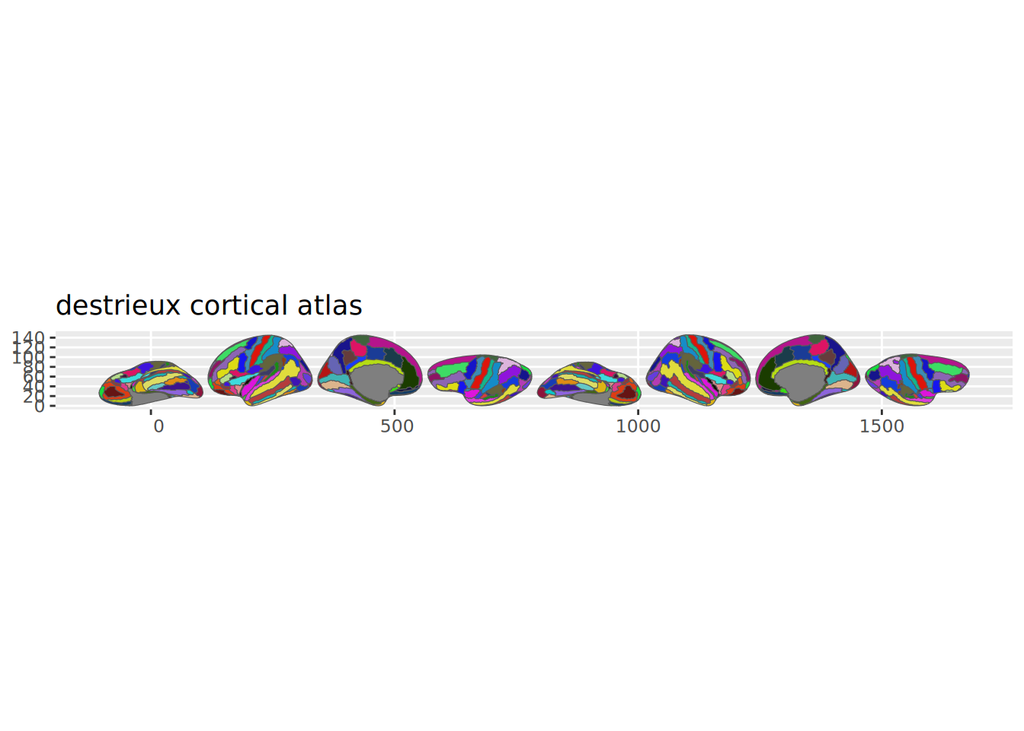

```r
# changer les noms dans les tableaux pour que ca fit avec ceux de l'atlas
posthoc_ct_dst <- posthoc_ct_dst %>%
  mutate(region = recode(region,

  "mr_y_smri__thk__dst__gcn"    = "G_cuneus",
  "mr_y_smri__thk__dst__gcpd"   = "G_cingul-Post-dorsal",
  "mr_y_smri__thk__dst__gcpv"   = "G_cingul-Post-ventral",
  "mr_y_smri__thk__dst__gfio"   = "G_front_inf-Opercular",
  "mr_y_smri__thk__dst__gfiob"  = "G_front_inf-Orbital",
  "mr_y_smri__thk__dst__gfit"   = "G_front_inf-Triangul",
  "mr_y_smri__thk__dst__gfm"    = "G_front_middle",
  "mr_y_smri__thk__dst__gfs"    = "G_front_sup",
  "mr_y_smri__thk__dst__gilsci" = "G_Ins_lg_and_S_cent_ins",
  "mr_y_smri__thk__dst__gis"    = "G_insular_short",
  "mr_y_smri__thk__dst__go"     = "G_orbital",
  "mr_y_smri__thk__dst__gom"    = "G_occipital_middle",
  "mr_y_smri__thk__dst__gos"    = "G_occipital_sup",
  "mr_y_smri__thk__dst__gotlf"  = "G_oc-temp_lat-fusifor",
  "mr_y_smri__thk__dst__gotml"  = "G_oc-temp_med-Lingual",
  "mr_y_smri__thk__dst__gotmp"  = "G_oc-temp_med-Parahip",
  "mr_y_smri__thk__dst__gpc"    = "G_postcentral",
  "mr_y_smri__thk__dst__gpia"   = "G_pariet_inf-Angular",
  "mr_y_smri__thk__dst__gpis"   = "G_pariet_inf-Supramar",
  "mr_y_smri__thk__dst__gprcn"  = "G_precuneus",
  "mr_y_smri__thk__dst__gprct"  = "G_precentral",
  "mr_y_smri__thk__dst__gps"    = "G_parietal_sup",
  "mr_y_smri__thk__dst__gr"     = "G_rectus",
  "mr_y_smri__thk__dst__gs"     = "G_subcallosal",
  "mr_y_smri__thk__dst__gsca"   = "G_and_S_cingul-Ant",
  "mr_y_smri__thk__dst__gscma"  = "G_and_S_cingul-Mid-Ant",
  "mr_y_smri__thk__dst__gscmp"  = "G_and_S_cingul-Mid-Post",
  "mr_y_smri__thk__dst__gsfm"   = "G_and_S_frontomargin",
  "mr_y_smri__thk__dst__gsoi"   = "G_and_S_occipital_inf",
  "mr_y_smri__thk__dst__gspc"   = "G_and_S_paracentral",
  "mr_y_smri__thk__dst__gssc"   = "G_and_S_subcentral",
  "mr_y_smri__thk__dst__gstf"   = "G_and_S_transv_frontopol",
  "mr_y_smri__thk__dst__gti"    = "G_temporal_inf",
  "mr_y_smri__thk__dst__gtm"    = "G_temporal_middle",
  "mr_y_smri__thk__dst__gtsgtt" = "G_temp_sup-G_T_transv",
  "mr_y_smri__thk__dst__gtsl"   = "G_temp_sup-Lateral",
  "mr_y_smri__thk__dst__gtspp"  = "G_temp_sup-Plan_polar",
  "mr_y_smri__thk__dst__gtspt"  = "G_temp_sup-Plan_tempo",
  "mr_y_smri__thk__dst__lfah"   = "Lat_Fis-ant-Horizont",
  "mr_y_smri__thk__dst__lfav"   = "Lat_Fis-ant-Vertical",
  "mr_y_smri__thk__dst__lfp"    = "Lat_Fis-post",
  "mr_y_smri__thk__dst__pocc"   = "Pole_occipital",
  "mr_y_smri__thk__dst__ptmp"   = "Pole_temporal",
  "mr_y_smri__thk__dst__sc"     = "S_central",
  "mr_y_smri__thk__dst__scc"    = "S_calcarine",
  "mr_y_smri__thk__dst__scia"   = "S_circular_insula_ant",
  "mr_y_smri__thk__dst__scii"   = "S_circular_insula_inf",
  "mr_y_smri__thk__dst__scis"   = "S_circular_insula_sup",
  "mr_y_smri__thk__dst__scm"    = "S_cingul-Marginalis",
  "mr_y_smri__thk__dst__scta"   = "S_collat_transv_ant",
  "mr_y_smri__thk__dst__sctp"   = "S_collat_transv_post",
  "mr_y_smri__thk__dst__sfi"    = "S_front_inf",
  "mr_y_smri__thk__dst__sfm"    = "S_front_middle",
  "mr_y_smri__thk__dst__sfs"    = "S_front_sup",
  "mr_y_smri__thk__dst__sipj"   = "S_interm_prim-Jensen",
  "mr_y_smri__thk__dst__sipt"   = "S_intrapariet_and_P_trans",
  "mr_y_smri__thk__dst__soa"    = "S_occipital_ant",
  "mr_y_smri__thk__dst__sohs"   = "S_orbital-H_Shaped",
  "mr_y_smri__thk__dst__sol"    = "S_orbital_lateral",
  "mr_y_smri__thk__dst__somo"   = "S_orbital_med-olfact",
  "mr_y_smri__thk__dst__soml"   = "S_oc_middle_and_Lunatus",
  "mr_y_smri__thk__dst__sost"   = "S_oc_sup_and_transversal",
  "mr_y_smri__thk__dst__sotl"   = "S_oc-temp_lat",
  "mr_y_smri__thk__dst__sotml"  = "S_oc-temp_med_and_Lingual",
  "mr_y_smri__thk__dst__spc"    = "S_pericallosal",
  "mr_y_smri__thk__dst__spct"   = "S_postcentral",
  "mr_y_smri__thk__dst__spo"    = "S_parieto_occipital",
  "mr_y_smri__thk__dst__sprip"  = "S_precentral-inf-part",
  "mr_y_smri__thk__dst__sprsp"  = "S_precentral-sup-part",
  "mr_y_smri__thk__dst__sso"    = "S_suborbital",
  "mr_y_smri__thk__dst__ssp"    = "S_subparietal",
  "mr_y_smri__thk__dst__sti"    = "S_temporal_inf",
  "mr_y_smri__thk__dst__sts"    = "S_temporal_sup",
  "mr_y_smri__thk__dst__stt"    = "S_temporal_transverse"

  ))

posthoc_ct_dst_0_1 <- posthoc_ct_dst %>%
  filter(contrast == "co_longi0 - co_longi1")

posthoc_ct_dst_0_1_ses02 <- posthoc_ct_dst_0_1 %>%
  filter(session_id == "ses-02A")

posthoc_ct_dst_0_1_ses04 <- posthoc_ct_dst_0_1 %>%
  filter(session_id == "ses-04A")

posthoc_ct_dst_0_1_ses06 <- posthoc_ct_dst_0_1 %>%
  filter(session_id == "ses-06A")

plot(destrieux())
```

```r
# 2

ct_dst_c01_ses02_p1 <- ggplot(posthoc_ct_dst_0_1_ses02) +
  geom_brain(
    atlas = destrieux(),
    mapping = aes(fill = estimate)
  )
ggsave(
  filename = "ct_dst_c01_ses02_p1.png",
  plot = ct_dst_c01_ses02_p1,
  path = here("results/brainmaps"
))
```

```
## Merging atlas and data by region.
```

```r
ct_dst_c01_ses02_p05 <- ggplot(posthoc_ct_dst_0_1_ses02 %>% filter(p.value < 0.05)) +
  geom_brain(
    atlas = destrieux(),
    aes(fill = estimate)
  )

ggsave(
  filename = "ct_dst_c01_ses02_p05.png",
  plot = ct_dst_c01_ses02_p05,
  path = here("results/brainmaps")
)
```

```
## Merging atlas and data by region.
```

```r
# 4
ct_dst_c01_ses04_p1 <- ggplot(posthoc_ct_dst_0_1_ses04) +
  geom_brain(
    atlas = destrieux(),
    mapping = aes(fill = estimate)
  )

ggsave(
  filename = "ct_dst_c01_ses04_p1.png",
  plot = ct_dst_c01_ses04_p1,
  path = here("results/brainmaps")
)
```

```
## Merging atlas and data by region.
```

```r
ct_dst_c01_ses04_p05 <- ggplot(posthoc_ct_dst_0_1_ses04 %>% filter(p.value < 0.05)) +
  geom_brain(
    atlas = destrieux(),
    aes(fill = estimate)
  )

ggsave(
  filename = "ct_dst_c01_ses04_p05.png",
  plot = ct_dst_c01_ses04_p05,
  path = here("results/brainmaps")
)
```

```
## Merging atlas and data by region.
```

```r
# 6
ct_dst_c01_ses06_p1 <- ggplot(posthoc_ct_dst_0_1_ses06) +
  geom_brain(
    atlas = destrieux(),
    mapping = aes(fill = estimate)
  )
ggsave(
  filename = "ct_dst_c01_ses06_p1.png",
  plot = ct_dst_c01_ses06_p1,
  path = here("results/brainmaps")
)
```

```
## Merging atlas and data by region.
```

```r
ct_dst_c01_ses06_p05 <-  ggplot(posthoc_ct_dst_0_1_ses06 %>% filter(p.value < 0.05)) +
  geom_brain(
    atlas = destrieux(),
    aes(fill = estimate)
  )
ggsave(
  filename = "ct_dst_c01_ses06_p05.png",
  plot = ct_dst_c01_ses06_p05,
  path = here("results/brainmaps")
)
```

```
## Merging atlas and data by region.
```

```r
posthoc_ct_dst_0_2 <- posthoc_ct_dst %>%
  filter(contrast == "co_longi0 - co_longi2")

posthoc_ct_dst_0_2_ses02 <- posthoc_ct_dst_0_2 %>%
  filter(session_id == "ses-02A")

posthoc_ct_dst_0_2_ses04 <- posthoc_ct_dst_0_2 %>%
  filter(session_id == "ses-04A")

posthoc_ct_dst_0_2_ses06 <- posthoc_ct_dst_0_2 %>%
  filter(session_id == "ses-06A")

# 2

ct_dst_c02_ses02_p1 <- ggplot(posthoc_ct_dst_0_2_ses02) +
  geom_brain(
    atlas = destrieux(),
    mapping = aes(fill = estimate)
  )
ggsave(
  filename = "ct_dst_c02_ses02_p1.png",
  plot = ct_dst_c02_ses02_p1,
  path = here("results/brainmaps")
)
```

```
## Merging atlas and data by region.
```

```r
ct_dst_c02_ses02_p05 <- ggplot(posthoc_ct_dst_0_2_ses02 %>% filter(p.value < 0.05)) +
  geom_brain(
    atlas = destrieux(),
    aes(fill = estimate)
  )

ggsave(
  filename = "ct_dst_c02_ses02_p05.png",
  plot = ct_dst_c02_ses02_p05,
  path = here("results/brainmaps")
)
```

```
## Merging atlas and data by region.
```

```r
# 4
ct_dst_c02_ses04_p1 <- ggplot(posthoc_ct_dst_0_2_ses04) +
  geom_brain(
    atlas = destrieux(),
    mapping = aes(fill = estimate)
  )

ggsave(
  filename = "ct_dst_c02_ses04_p1.png",
  plot = ct_dst_c02_ses04_p1,
  path = here("results/brainmaps")
)
```

```
## Merging atlas and data by region.
```

```r
ct_dst_c02_ses04_p05 <- ggplot(posthoc_ct_dst_0_2_ses04 %>% filter(p.value < 0.05)) +
  geom_brain(
    atlas = destrieux(),
    aes(fill = estimate)
  )

ggsave(
  filename = "ct_dst_c02_ses04_p05.png",
  plot = ct_dst_c02_ses04_p05,
  path = here("results/brainmaps")
)
```

```
## Merging atlas and data by region.
```

```r
# 6
ct_dst_c02_ses06_p1 <- ggplot(posthoc_ct_dst_0_2_ses06) +
  geom_brain(
    atlas = destrieux(),
    mapping = aes(fill = estimate)
  )
ggsave(
  filename = "ct_dst_c02_ses06_p1.png",
  plot = ct_dst_c02_ses06_p1,
  path = here("results/brainmaps")
)
```

```
## Merging atlas and data by region.
```

```r
ct_dst_c02_ses06_p05 <-  ggplot(posthoc_ct_dst_0_2_ses06 %>% filter(p.value < 0.05)) +
  geom_brain(
    atlas = destrieux(),
    aes(fill = estimate)
  )

ggsave(
  filename = "ct_dst_c02_ses06_p05.png",
  plot = ct_dst_c02_ses06_p05,
  path = here("results/brainmaps")
)
```

```
## Merging atlas and data by region.
```

```r
posthoc_ct_dst_1_2 <- posthoc_ct_dst %>%
  filter(contrast == "co_longi1 - co_longi2")

posthoc_ct_dst_1_2_ses02 <- posthoc_ct_dst_1_2 %>%
  filter(session_id == "ses-02A")

posthoc_ct_dst_1_2_ses04 <- posthoc_ct_dst_1_2 %>%
  filter(session_id == "ses-04A")

posthoc_ct_dst_1_2_ses06 <- posthoc_ct_dst_1_2 %>%
  filter(session_id == "ses-06A")

# 2

ct_dst_c12_ses02_p1 <- ggplot(posthoc_ct_dst_1_2_ses02) +
  geom_brain(
    atlas = destrieux(),
    mapping = aes(fill = estimate)
  )
ggsave(
  filename = "ct_dst_c12_ses02_p1.png",
  plot = ct_dst_c12_ses02_p1,
  path = here("results/brainmaps")
)
```

```
## Merging atlas and data by region.
```

```r
ct_dst_c12_ses02_p05 <- ggplot(posthoc_ct_dst_1_2_ses02 %>% filter(p.value < 0.05)) +
  geom_brain(
    atlas = destrieux(),
    aes(fill = estimate)
  )

ggsave(
  filename = "ct_dst_c12_ses02_p05.png",
  plot = ct_dst_c12_ses02_p05,
  path = here("results/brainmaps")
)
```

```
## Merging atlas and data by region.
```

```r
# 4
ct_dst_c12_ses04_p1 <- ggplot(posthoc_ct_dst_1_2_ses04) +
  geom_brain(
    atlas = destrieux(),
    mapping = aes(fill = estimate)
  )

ggsave(
  filename = "ct_dst_c12_ses04_p1.png",
  plot = ct_dst_c12_ses04_p1,
  path = here("results/brainmaps")
)
```

```
## Merging atlas and data by region.
```

```r
ct_dst_c12_ses04_p05 <- ggplot(posthoc_ct_dst_1_2_ses04 %>% filter(p.value < 0.05)) +
  geom_brain(
    atlas = destrieux(),
    aes(fill = estimate)
  )

ggsave(
  filename = "ct_dst_c12_ses04_p05.png",
  plot = ct_dst_c12_ses04_p05,
  path = here("results/brainmaps")
)
```

```
## Merging atlas and data by region.
```

```r
# 6
ct_dst_c12_ses06_p1 <- ggplot(posthoc_ct_dst_1_2_ses06) +
  geom_brain(
    atlas = destrieux(),
    mapping = aes(fill = estimate)
  )
ggsave(
  filename = "ct_dst_c12_ses06_p1.png",
  plot = ct_dst_c12_ses06_p1,
  path = here("results/brainmaps")
)
```

```
## Merging atlas and data by region.
```

```r
ct_dst_c12_ses06_p05 <-  ggplot(posthoc_ct_dst_1_2_ses06 %>% filter(p.value < 0.05)) +
  geom_brain(
    atlas = destrieux(),
    aes(fill = estimate)
  )

ggsave(
  filename = "ct_dst_c12_ses06_p05.png",
  plot = ct_dst_c12_ses06_p05,
  path = here("results/brainmaps")
)
```

```
## Merging atlas and data by region.
```

```r
ggseg.formats::atlas_regions(destrieux())
```

```
##  [1] "G_and_S_cingul-Ant"        "G_and_S_cingul-Mid-Ant"
##  [3] "G_and_S_cingul-Mid-Post"   "G_and_S_frontomargin"
##  [5] "G_and_S_occipital_inf"     "G_and_S_paracentral"
##  [7] "G_and_S_subcentral"        "G_and_S_transv_frontopol"
##  [9] "G_cingul-Post-dorsal"      "G_cingul-Post-ventral"
## [11] "G_cuneus"                  "G_front_inf-Opercular"
## [13] "G_front_inf-Orbital"       "G_front_inf-Triangul"
## [15] "G_front_middle"            "G_front_sup"
## [17] "G_Ins_lg_and_S_cent_ins"   "G_insular_short"
## [19] "G_oc-temp_lat-fusifor"     "G_oc-temp_med-Lingual"
## [21] "G_oc-temp_med-Parahip"     "G_occipital_middle"
## [23] "G_occipital_sup"           "G_orbital"
## [25] "G_pariet_inf-Angular"      "G_pariet_inf-Supramar"
## [27] "G_parietal_sup"            "G_postcentral"
## [29] "G_precentral"              "G_precuneus"
```

[output cut: 22 more lines]

```r
# changer les noms dans les tableaux pour que ca fit avec ceux de l'atlas
posthoc_vol_dst <- posthoc_vol_dst %>%
  mutate(region = recode(region,
  "mr_y_smri__vol__dst__gcn"    = "G_cuneus",
  "mr_y_smri__vol__dst__gcpd"   = "G_cingul-Post-dorsal",
  "mr_y_smri__vol__dst__gcpv"   = "G_cingul-Post-ventral",
  "mr_y_smri__vol__dst__gfio"   = "G_front_inf-Opercular",
  "mr_y_smri__vol__dst__gfiob"  = "G_front_inf-Orbital",
  "mr_y_smri__vol__dst__gfit"   = "G_front_inf-Triangul",
  "mr_y_smri__vol__dst__gfm"    = "G_front_middle",
  "mr_y_smri__vol__dst__gfs"    = "G_front_sup",
  "mr_y_smri__vol__dst__gilsci" = "G_Ins_lg_and_S_cent_ins",
  "mr_y_smri__vol__dst__gis"    = "G_insular_short",
  "mr_y_smri__vol__dst__go"     = "G_orbital",
  "mr_y_smri__vol__dst__gom"    = "G_occipital_middle",
  "mr_y_smri__vol__dst__gos"    = "G_occipital_sup",
  "mr_y_smri__vol__dst__gotlf"  = "G_oc-temp_lat-fusifor",
  "mr_y_smri__vol__dst__gotml"  = "G_oc-temp_med-Lingual",
  "mr_y_smri__vol__dst__gotmp"  = "G_oc-temp_med-Parahip",
  "mr_y_smri__vol__dst__gpc"    = "G_postcentral",
  "mr_y_smri__vol__dst__gpia"   = "G_pariet_inf-Angular",
  "mr_y_smri__vol__dst__gpis"   = "G_pariet_inf-Supramar",
  "mr_y_smri__vol__dst__gprcn"  = "G_precuneus",
  "mr_y_smri__vol__dst__gprct"  = "G_precentral",
  "mr_y_smri__vol__dst__gps"    = "G_parietal_sup",
  "mr_y_smri__vol__dst__gr"     = "G_rectus",
  "mr_y_smri__vol__dst__gs"     = "G_subcallosal",
  "mr_y_smri__vol__dst__gsca"   = "G_and_S_cingul-Ant",
  "mr_y_smri__vol__dst__gscma"  = "G_and_S_cingul-Mid-Ant",
  "mr_y_smri__vol__dst__gscmp"  = "G_and_S_cingul-Mid-Post",
  "mr_y_smri__vol__dst__gsfm"   = "G_and_S_frontomargin",
  "mr_y_smri__vol__dst__gsoi"   = "G_and_S_occipital_inf",
  "mr_y_smri__vol__dst__gspc"   = "G_and_S_paracentral",
  "mr_y_smri__vol__dst__gssc"   = "G_and_S_subcentral",
  "mr_y_smri__vol__dst__gstf"   = "G_and_S_transv_frontopol",
  "mr_y_smri__vol__dst__gti"    = "G_temporal_inf",
  "mr_y_smri__vol__dst__gtm"    = "G_temporal_middle",
  "mr_y_smri__vol__dst__gtsgtt" = "G_temp_sup-G_T_transv",
  "mr_y_smri__vol__dst__gtsl"   = "G_temp_sup-Lateral",
  "mr_y_smri__vol__dst__gtspp"  = "G_temp_sup-Plan_polar",
  "mr_y_smri__vol__dst__gtspt"  = "G_temp_sup-Plan_tempo",
  "mr_y_smri__vol__dst__lfah"   = "Lat_Fis-ant-Horizont",
  "mr_y_smri__vol__dst__lfav"   = "Lat_Fis-ant-Vertical",
  "mr_y_smri__vol__dst__lfp"    = "Lat_Fis-post",
  "mr_y_smri__vol__dst__pocc"   = "Pole_occipital",
  "mr_y_smri__vol__dst__ptmp"   = "Pole_temporal",
  "mr_y_smri__vol__dst__sc"     = "S_central",
  "mr_y_smri__vol__dst__scc"    = "S_calcarine",
  "mr_y_smri__vol__dst__scia"   = "S_circular_insula_ant",
  "mr_y_smri__vol__dst__scii"   = "S_circular_insula_inf",
  "mr_y_smri__vol__dst__scis"   = "S_circular_insula_sup",
  "mr_y_smri__vol__dst__scm"    = "S_cingul-Marginalis",
  "mr_y_smri__vol__dst__scta"   = "S_collat_transv_ant",
  "mr_y_smri__vol__dst__sctp"   = "S_collat_transv_post",
  "mr_y_smri__vol__dst__sfi"    = "S_front_inf",
  "mr_y_smri__vol__dst__sfm"    = "S_front_middle",
  "mr_y_smri__vol__dst__sfs"    = "S_front_sup",
  "mr_y_smri__vol__dst__sipj"   = "S_interm_prim-Jensen",
  "mr_y_smri__vol__dst__sipt"   = "S_intrapariet_and_P_trans",
  "mr_y_smri__vol__dst__soa"    = "S_occipital_ant",
  "mr_y_smri__vol__dst__sohs"   = "S_orbital-H_Shaped",
  "mr_y_smri__vol__dst__sol"    = "S_orbital_lateral",
  "mr_y_smri__vol__dst__soml"   = "S_oc_middle_and_Lunatus",
  "mr_y_smri__vol__dst__somo"   = "S_orbital_med-olfact",
  "mr_y_smri__vol__dst__sost"   = "S_oc_sup_and_transversal",
  "mr_y_smri__vol__dst__sotl"   = "S_oc-temp_lat",
  "mr_y_smri__vol__dst__sotml"  = "S_oc-temp_med_and_Lingual",
  "mr_y_smri__vol__dst__spc"    = "S_pericallosal",
  "mr_y_smri__vol__dst__spct"   = "S_postcentral",
  "mr_y_smri__vol__dst__spo"    = "S_parieto_occipital",
  "mr_y_smri__vol__dst__sprip"  = "S_precentral-inf-part",
  "mr_y_smri__vol__dst__sprsp"  = "S_precentral-sup-part",
  "mr_y_smri__vol__dst__sso"    = "S_suborbital",
  "mr_y_smri__vol__dst__ssp"    = "S_subparietal",
  "mr_y_smri__vol__dst__sti"    = "S_temporal_inf",
  "mr_y_smri__vol__dst__sts"    = "S_temporal_sup",
  "mr_y_smri__vol__dst__stt"    = "S_temporal_transverse"

  ))

posthoc_vol_dst_0_1 <- posthoc_vol_dst %>%
  filter(contrast == "co_longi0 - co_longi1")

posthoc_vol_dst_0_1_ses02 <- posthoc_vol_dst_0_1 %>%
  filter(session_id == "ses-02A")

posthoc_vol_dst_0_1_ses04 <- posthoc_vol_dst_0_1 %>%
  filter(session_id == "ses-04A")

posthoc_vol_dst_0_1_ses06 <- posthoc_vol_dst_0_1 %>%
  filter(session_id == "ses-06A")


# 2

vol_dst_c01_ses02_p1 <- ggplot(posthoc_vol_dst_0_1_ses02) +
  geom_brain(
    atlas = destrieux(),
    mapping = aes(fill = estimate)
  )
ggsave(
  filename = "vol_dst_c01_ses02_p1.png",
  plot = vol_dst_c01_ses02_p1,
  path = here("results/brainmaps")
)
```

```
## Merging atlas and data by region.
```

```r
vol_dst_c01_ses02_p05 <- ggplot(posthoc_vol_dst_0_1_ses02 %>% filter(p.value < 0.05)) +
  geom_brain(
    atlas = destrieux(),
    aes(fill = estimate)
  )

ggsave(
  filename = "vol_dst_c01_ses02_p05.png",
  plot = vol_dst_c01_ses02_p05,
  path = here("results/brainmaps")
)
```

```
## Merging atlas and data by region.
```

```r
# 4
vol_dst_c01_ses04_p1 <- ggplot(posthoc_vol_dst_0_1_ses04) +
  geom_brain(
    atlas = destrieux(),
    mapping = aes(fill = estimate)
  )

ggsave(
  filename = "vol_dst_c01_ses04_p1.png",
  plot = vol_dst_c01_ses04_p1,
  path = here("results/brainmaps")
)
```

```
## Merging atlas and data by region.
```

```r
vol_dst_c01_ses04_p05 <- ggplot(posthoc_vol_dst_0_1_ses04 %>% filter(p.value < 0.05)) +
  geom_brain(
    atlas = destrieux(),
    aes(fill = estimate)
  )

ggsave(
  filename = "vol_dst_c01_ses04_p05.png",
  plot = vol_dst_c01_ses04_p05,
  path = here("results/brainmaps")
)
```

```
## Merging atlas and data by region.
```

```r
# 6
vol_dst_c01_ses06_p1 <- ggplot(posthoc_vol_dst_0_1_ses06) +
  geom_brain(
    atlas = destrieux(),
    mapping = aes(fill = estimate)
  )
ggsave(
  filename = "vol_dst_c01_ses06_p1.png",
  plot = vol_dst_c01_ses06_p1,
  path = here("results/brainmaps")
)
```

```
## Merging atlas and data by region.
```

```r
vol_dst_c01_ses06_p05 <-  ggplot(posthoc_vol_dst_0_1_ses06 %>% filter(p.value < 0.05)) +
  geom_brain(
    atlas = destrieux(),
    aes(fill = estimate)
  )
ggsave(
  filename = "vol_dst_c01_ses06_p05.png",
  plot = vol_dst_c01_ses06_p05,
  path = here("results/brainmaps")
)
```

```
## Merging atlas and data by region.
```

```r
posthoc_vol_dst_0_2 <- posthoc_vol_dst %>%
  filter(contrast == "co_longi0 - co_longi2")

posthoc_vol_dst_0_2_ses02 <- posthoc_vol_dst_0_2 %>%
  filter(session_id == "ses-02A")

posthoc_vol_dst_0_2_ses04 <- posthoc_vol_dst_0_2 %>%
  filter(session_id == "ses-04A")

posthoc_vol_dst_0_2_ses06 <- posthoc_vol_dst_0_2 %>%
  filter(session_id == "ses-06A")


# 2

vol_dst_c02_ses02_p1 <- ggplot(posthoc_vol_dst_0_2_ses02) +
  geom_brain(
    atlas = destrieux(),
    mapping = aes(fill = estimate)
  )
ggsave(
  filename = "vol_dst_c02_ses02_p1.png",
  plot = vol_dst_c02_ses02_p1,
  path =here("results/brainmaps")
)
```

```
## Merging atlas and data by region.
```

```r
vol_dst_c02_ses02_p05 <- ggplot(posthoc_vol_dst_0_2_ses02 %>% filter(p.value < 0.05)) +
  geom_brain(
    atlas = destrieux(),
    aes(fill = estimate)
  )

ggsave(
  filename = "vol_dst_c02_ses02_p05.png",
  plot = vol_dst_c02_ses02_p05,
  path = here("results/brainmaps")
)
```

```
## Merging atlas and data by region.
```

```r
# 4
vol_dst_c02_ses04_p1 <- ggplot(posthoc_vol_dst_0_2_ses04) +
  geom_brain(
    atlas = destrieux(),
    mapping = aes(fill = estimate)
  )

ggsave(
  filename = "vol_dst_c02_ses04_p1.png",
  plot = vol_dst_c02_ses04_p1,
  path = here("results/brainmaps")
)
```

```
## Merging atlas and data by region.
```

```r
vol_dst_c02_ses04_p05 <- ggplot(posthoc_vol_dst_0_2_ses04 %>% filter(p.value < 0.05)) +
  geom_brain(
    atlas = destrieux(),
    aes(fill = estimate)
  )

ggsave(
  filename = "vol_dst_c02_ses04_p05.png",
  plot = vol_dst_c02_ses04_p05,
  path = here("results/brainmaps")
)
```

```
## Merging atlas and data by region.
```

```r
# 6
vol_dst_c02_ses06_p1 <- ggplot(posthoc_vol_dst_0_2_ses06) +
  geom_brain(
    atlas = destrieux(),
    mapping = aes(fill = estimate)
  )
ggsave(
  filename = "vol_dst_c02_ses06_p1.png",
  plot = vol_dst_c02_ses06_p1,
  path = here("results/brainmaps")
)
```

```
## Merging atlas and data by region.
```

```r
vol_dst_c02_ses06_p05 <-  ggplot(posthoc_vol_dst_0_2_ses06 %>% filter(p.value < 0.05)) +
  geom_brain(
    atlas = destrieux(),
    aes(fill = estimate)
  )
ggsave(
  filename = "vol_dst_c02_ses06_p05.png",
  plot = vol_dst_c02_ses06_p05,
  path = here("results/brainmaps")
)
```

```
## Merging atlas and data by region.
```

```r
posthoc_vol_dst_1_2 <- posthoc_vol_dst %>%
  filter(contrast == "co_longi1 - co_longi2")

posthoc_vol_dst_1_2_ses02 <- posthoc_vol_dst_1_2 %>%
  filter(session_id == "ses-02A")

posthoc_vol_dst_1_2_ses04 <- posthoc_vol_dst_1_2 %>%
  filter(session_id == "ses-04A")

posthoc_vol_dst_1_2_ses06 <- posthoc_vol_dst_1_2 %>%
  filter(session_id == "ses-06A")


# 2

vol_dst_c12_ses02_p1 <- ggplot(posthoc_vol_dst_1_2_ses02) +
  geom_brain(
    atlas = destrieux(),
    mapping = aes(fill = estimate)
  )
ggsave(
  filename = "vol_dst_c12_ses02_p1.png",
  plot = vol_dst_c12_ses02_p1,
  path = here("results/brainmaps")
)
```

```
## Merging atlas and data by region.
```

```r
vol_dst_c12_ses02_p05 <- ggplot(posthoc_vol_dst_1_2_ses02 %>% filter(p.value < 0.05)) +
  geom_brain(
    atlas = destrieux(),
    aes(fill = estimate)
  )

ggsave(
  filename = "vol_dst_c12_ses02_p05.png",
  plot = vol_dst_c12_ses02_p05,
  path = here("results/brainmaps")
)
```

```
## Merging atlas and data by region.
```

```r
# 4
vol_dst_c12_ses04_p1 <- ggplot(posthoc_vol_dst_1_2_ses04) +
  geom_brain(
    atlas = destrieux(),
    mapping = aes(fill = estimate)
  )

ggsave(
  filename = "vol_dst_c12_ses04_p1.png",
  plot = vol_dst_c12_ses04_p1,
  path = here("results/brainmaps")
)
```

```
## Merging atlas and data by region.
```

```r
vol_dst_c12_ses04_p05 <- ggplot(posthoc_vol_dst_1_2_ses04 %>% filter(p.value < 0.05)) +
  geom_brain(
    atlas = destrieux(),
    aes(fill = estimate)
  )

ggsave(
  filename = "vol_dst_c12_ses04_p05.png",
  plot = vol_dst_c12_ses04_p05,
  path = here("results/brainmaps")
)
```

```
## Merging atlas and data by region.
```

```r
# 6
vol_dst_c12_ses06_p1 <- ggplot(posthoc_vol_dst_1_2_ses06) +
  geom_brain(
    atlas = destrieux(),
    mapping = aes(fill = estimate)
  )
ggsave(
  filename = "vol_dst_c12_ses06_p1.png",
  plot = vol_dst_c12_ses06_p1,
  path = here("results/brainmaps")
)
```

```
## Merging atlas and data by region.
```

```r
vol_dst_c12_ses06_p05 <-  ggplot(posthoc_vol_dst_1_2_ses06 %>% filter(p.value < 0.05)) +
  geom_brain(
    atlas = destrieux(),
    aes(fill = estimate)
  )
ggsave(
  filename = "vol_dst_c12_ses06_p05.png",
  plot = vol_dst_c12_ses06_p05,
  path = here("results/brainmaps")
)
```

```
## Merging atlas and data by region.
```